# CS2_SJ

Stephen Johnson

April 9, 2019

## 2. Clean your Raw Data

## a. Read the csv into R and take a look at the data set. Output how many rows and columns the data.frame is.

```r
setwd("C:\\Users\\sj103\\OneDrive\\Documents\\MSDS_Working\\CaseStudy_02")
attrition <-read.csv(file="CaseStudy2-data - Copy.csv", header=TRUE, sep=",")
summary(attrition)
```

```
##       Age        Attrition            BusinessTravel   DailyRate
##  Min.   :18.00   No :1233   Non-Travel       : 150   Min.   : 102.0
##  1st Qu.:30.00   Yes: 237   Travel_Frequently: 277   1st Qu.: 465.0
##  Median :36.00              Travel_Rarely    :1043   Median : 802.0
##  Mean   :36.92                                       Mean   : 802.5
##  3rd Qu.:43.00                                       3rd Qu.:1157.0
##  Max.   :60.00                                       Max.   :1499.0
##
##                   Department  DistanceFromHome   Education
##  Human Resources       : 63   Min.   : 1.000   Min.   :1.000
##  Research & Development:961   1st Qu.: 2.000   1st Qu.:2.000
##  Sales                 :446   Median : 7.000   Median :3.000
##                               Mean   : 9.193   Mean   :2.913
##                               3rd Qu.:14.000   3rd Qu.:4.000
##                               Max.   :29.000   Max.   :5.000
##
##           EducationField EmployeeCount EmployeeNumber
##  Human Resources : 27    Min.   :1     Min.   :   1.0
##  Life Sciences   :606    1st Qu.:1     1st Qu.: 491.2
##  Marketing       :159    Median :1     Median :1020.5
##  Medical         :464    Mean   :1     Mean   :1024.9
##  Other           : 82    3rd Qu.:1     3rd Qu.:1555.8
##  Technical Degree:132    Max.   :1     Max.   :2068.0
##
##  EnvironmentSatisfaction    Gender      HourlyRate     JobInvolvement
##  Min.   :1.000           Female:588   Min.   : 30.00   Min.   :1.00
##  1st Qu.:2.000           Male  :882   1st Qu.: 48.00   1st Qu.:2.00
##  Median :3.000                        Median : 66.00   Median :3.00
##  Mean   :2.722                        Mean   : 65.89   Mean   :2.73
##  3rd Qu.:4.000                        3rd Qu.: 83.75   3rd Qu.:3.00
##  Max.   :4.000                        Max.   :100.00   Max.   :4.00
##
##     JobLevel                          JobRole    JobSatisfaction
##  Min.   :1.000   Sales Executive          :326   Min.   :1.000
##  1st Qu.:1.000   Research Scientist       :292   1st Qu.:2.000
##  Median :2.000   Laboratory Technician    :259   Median :3.000
##  Mean   :2.064   Manufacturing Director   :145   Mean   :2.729
##  3rd Qu.:3.000   Healthcare Representative:131   3rd Qu.:4.000
##  Max.   :5.000   Manager                  :102   Max.   :4.000
##                  (Other)                  :215
```

[output cut: 25 more lines]

```
##  Min.   :0.000         Min.   :1.000   Min.   : 0.000   Min.   : 0.000
##  1st Qu.:2.000         1st Qu.:2.000   1st Qu.: 3.000   1st Qu.: 2.000
##  Median :3.000         Median :3.000   Median : 5.000   Median : 3.000
##  Mean   :2.799         Mean   :2.761   Mean   : 7.008   Mean   : 4.229
##  3rd Qu.:3.000         3rd Qu.:3.000   3rd Qu.: 9.000   3rd Qu.: 7.000
##  Max.   :6.000         Max.   :4.000   Max.   :40.000   Max.   :18.000
##
##  YearsSinceLastPromotion YearsWithCurrManager
##  Min.   : 0.000          Min.   : 0.000
##  1st Qu.: 0.000          1st Qu.: 2.000
##  Median : 1.000          Median : 3.000
##  Mean   : 2.188          Mean   : 4.123
##  3rd Qu.: 3.000          3rd Qu.: 7.000
##  Max.   :15.000          Max.   :17.000
##
```

```r
nrow(attrition)
```

```
## [1] 1470
```

```r
ncol(attrition)
```

```
## [1] 35
```

## b. Change the column names so that they do not have spaces, underscores, slashes, and the like.

```r
library(janitor)
attrition = attrition %>% clean_names()
# names(attrition)  = gsub("_","", names(attrition))
```

# c Some columns are, due to Qualtrics, malfunctioning.

# d Make sure your columns are the proper data types (i.e., numeric, character, etc.). If they are incorrect, convert them.

```r
str(attrition)
```

```
## 'data.frame':    1470 obs. of  35 variables:
##  $ age                       : int  41 49 37 33 27 32 59 30 38 36 ...
##  $ attrition                 : Factor w/ 2 levels "No","Yes": 2 1 2 1 1 1 1 1 1 1 ...
##  $ business_travel           : Factor w/ 3 levels "Non-Travel","Travel_Frequently",..: 3 2 3 2 3 2 3 3 2 3 ...
##  $ daily_rate                : int  1102 279 1373 1392 591 1005 1324 1358 216 1299 ...
##  $ department                : Factor w/ 3 levels "Human Resources",..: 3 2 2 2 2 2 2 2 2 2 ...
##  $ distance_from_home        : int  1 8 2 3 2 2 3 24 23 27 ...
##  $ education                 : int  2 1 2 4 1 2 3 1 3 3 ...
##  $ education_field           : Factor w/ 6 levels "Human Resources",..: 2 2 5 2 4 2 4 2 2 4 ...
##  $ employee_count            : int  1 1 1 1 1 1 1 1 1 1 ...
##  $ employee_number           : int  1 2 4 5 7 8 10 11 12 13 ...
##  $ environment_satisfaction  : int  2 3 4 4 1 4 3 4 4 3 ...
##  $ gender                    : Factor w/ 2 levels "Female","Male": 1 2 2 1 2 2 1 2 2 2 ...
##  $ hourly_rate               : int  94 61 92 56 40 79 81 67 44 94 ...
##  $ job_involvement           : int  3 2 2 3 3 3 4 3 2 3 ...
```

[output cut: 21 more lines]

# 3. Preliminary Analysis

# a Remove all observations where the participant is under age 18. No further analysis of underage individuals is permitted by your client. Remove any other age outliers as you see fit, but be sure to tell what you’re doing and why.

```r
library(dplyr)
attrition = attrition %>% filter(age>=18)
```

# b Please provide (in table format or similar), descriptive statistics on at least 7 variables (age, Income, etc.). Create a simple histogram for two of them. Comment on the shape of the distribution in your markdown.

```r
library(ggplot2)
library(knitr)

summary(attrition %>% select(age,monthly_income,education,performance_rating,job_satisfaction,num_companies_worked,work_life_balance))
```

```
##       age        monthly_income    education     performance_rating
##  Min.   :18.00   Min.   : 1009   Min.   :1.000   Min.   :3.000
##  1st Qu.:30.00   1st Qu.: 2911   1st Qu.:2.000   1st Qu.:3.000
##  Median :36.00   Median : 4919   Median :3.000   Median :3.000
##  Mean   :36.92   Mean   : 6503   Mean   :2.913   Mean   :3.154
##  3rd Qu.:43.00   3rd Qu.: 8379   3rd Qu.:4.000   3rd Qu.:3.000
##  Max.   :60.00   Max.   :19999   Max.   :5.000   Max.   :4.000
##  job_satisfaction num_companies_worked work_life_balance
##  Min.   :1.000    Min.   :0.000        Min.   :1.000
##  1st Qu.:2.000    1st Qu.:1.000        1st Qu.:2.000
##  Median :3.000    Median :2.000        Median :3.000
##  Mean   :2.729    Mean   :2.693        Mean   :2.761
##  3rd Qu.:4.000    3rd Qu.:4.000        3rd Qu.:3.000
##  Max.   :4.000    Max.   :9.000        Max.   :4.000
```

```r
kable(summary(attrition %>% select(age,monthly_income,education,performance_rating,job_satisfaction,num_companies_worked,work_life_balance)))
```

|  | age | monthly_income | education | performance_rating | job_satisfaction | num_companies_worked | work_life_balance |
| --- | --- | --- | --- | --- | --- | --- | --- |
|  | Min. :18.00 | Min. : 1009 | Min. :1.000 | Min. :3.000 | Min. :1.000 | Min. :0.000 | Min. :1.000 |
|  | 1st Qu.:30.00 | 1st Qu.: 2911 | 1st Qu.:2.000 | 1st Qu.:3.000 | 1st Qu.:2.000 | 1st Qu.:1.000 | 1st Qu.:2.000 |
|  | Median :36.00 | Median : 4919 | Median :3.000 | Median :3.000 | Median :3.000 | Median :2.000 | Median :3.000 |
|  | Mean :36.92 | Mean : 6503 | Mean :2.913 | Mean :3.154 | Mean :2.729 | Mean :2.693 | Mean :2.761 |
|  | 3rd Qu.:43.00 | 3rd Qu.: 8379 | 3rd Qu.:4.000 | 3rd Qu.:3.000 | 3rd Qu.:4.000 | 3rd Qu.:4.000 | 3rd Qu.:3.000 |
|  | Max. :60.00 | Max. :19999 | Max. :5.000 | Max. :4.000 | Max. :4.000 | Max. :9.000 | Max. :4.000 |

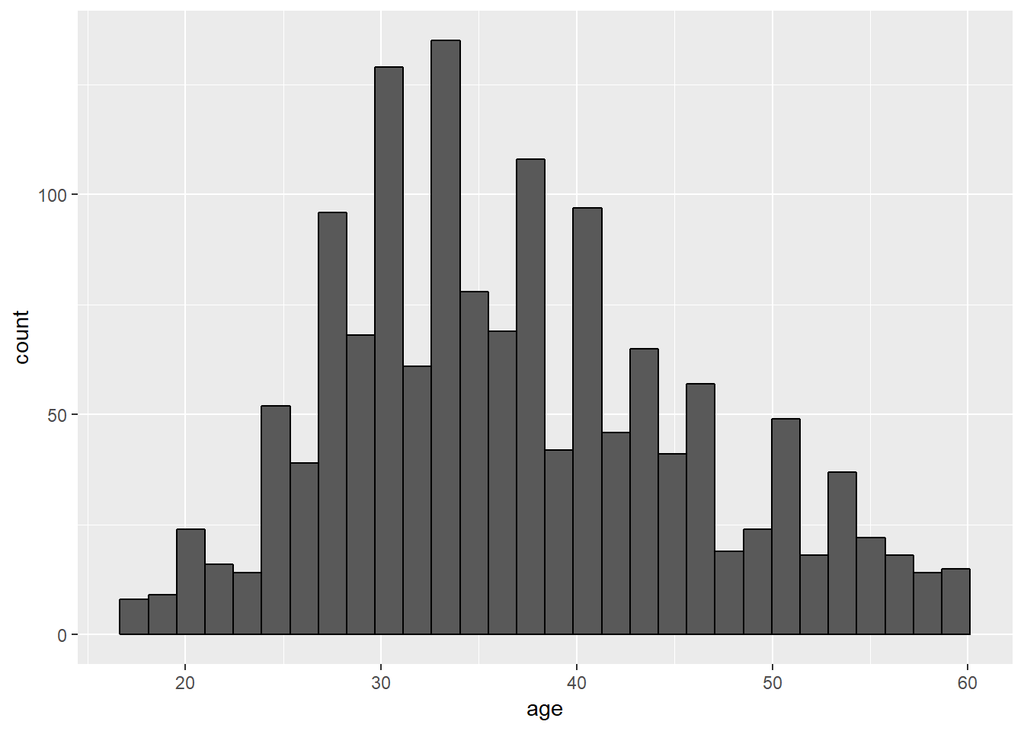

```r
attrition %>%
  ggplot(aes(x = age))+geom_histogram(color = 'black')
```

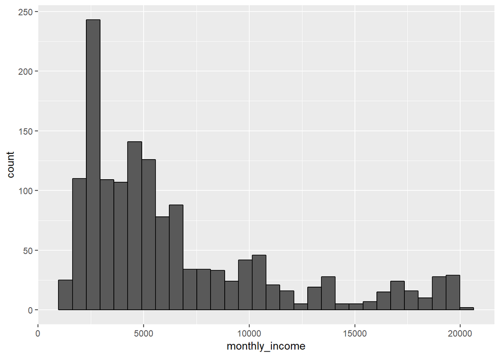

```r
attrition %>%
  ggplot(aes(x = monthly_income))+geom_histogram(color = 'black')
```

#c Give the frequencies (in table format or similar) for Gender, Education, and Occupation. They can be separate tables, if that’s your choice.

```r
kable(sapply(attrition %>% select(gender, education, job_role), function(x) table(x)))
```

| x | Freq |
| --- | --- |
| Female | 588 |
| Male | 882 |

| x | Freq |
| --- | --- |
| 1 | 170 |
| 2 | 282 |
| 3 | 572 |
| 4 | 398 |
| 5 | 48 |

| x | Freq |
| --- | --- |
| Healthcare Representative | 131 |
| Human Resources | 52 |
| Laboratory Technician | 259 |
| Manager | 102 |
| Manufacturing Director | 145 |
| Research Director | 80 |
| Research Scientist | 292 |
| Sales Executive | 326 |
| Sales Representative | 83 |

```r
table(attrition$gender)
```

```
##
## Female   Male
##    588    882
```

```r
table(attrition$education)
```

```
##
##   1   2   3   4   5
## 170 282 572 398  48
```

```r
table(attrition$job_role)
```

```
##
## Healthcare Representative           Human Resources
##                       131                        52
##     Laboratory Technician                   Manager
##                       259                       102
##    Manufacturing Director         Research Director
##                       145                        80
##        Research Scientist           Sales Executive
##                       292                       326
##      Sales Representative
##                        83
```